# Introduction to Geotechnical Hazards

CIVE70007 Geotechnical Hazards · Introduction

Peter J Stafford

p.stafford@imperial.ac.uk

Professor of Engineering Seismology

## Module Aims & Objectives

1. Introduce the fundamental elements of engineering seismology and seismic hazard assessment (including the effects of soil deposits at a site), together with basic concepts for other geohazards such as tsunamis, landslides and volcanoes
2. Enable you to understand the hazard and risk framework as a generic tool that can be applied to all types of geohazard (or indeed any hazard or loading scenario)
3. We don’t aim for specialist expertise in any given area, but rather a broad understanding that prepares you for:
   1. further training in specialised areas; and/or,
   2. interacting with established specialists in their respective fields

## Intended Learning Outcomes

On successfully completing this module, you should be able to:

1. Understand core features of the major types of geotechnical and geological hazard: ground shaking, tsunamis, landslides and volcanoes
2. Appreciate the common framework that links these different hazards
3. Perform seismic hazard analyses and characterise earthquake actions
4. Confidently interact with domain specialists in this field
5. Estimate the seismic response of soil layers
6. Evaluate the liquefaction potential of soil deposits using simplified methods
7. Estimate slope movements induced by seismic motion

## Syllabus

| Session | Topic | Staff |
| --- | --- | --- |
| Week 1 | Introduction to geohazards and the hazard & risk framework | PJS |
| Week 2 | Seismic sources, types of earthquakes, earthquake characteristics | PJS |
| Week 3 | Recurrence relationships, seismicity analysis, seismic recordings | PJS |
| Week 4 | Strong motion engineering seismology | PJS |
| Week 5 | Seismic hazard analysis | PJS |
| Week 6 | Epistemic uncertainty, representation in seismic codes | PJS |
| Week 7 | Fundamentals of wave propagation, dynamic soil properties and site effects. | DA |
| Week 8 | Site response analysis and its incorporation into PSHA | DA |
| Week 9 | Liquefaction: mechanisms, assessment of hazard and estimation of liquefaction induced deformations. | DA |
| Week 10 | Seismic Slope Stability | DA |

## Teaching & Assessment

- All lectures in this module are delivered **in person**
- All lectures are recorded
  - The recordings will be useful
  - The course covers a range of topics, many of which are new to you
  - Its important to follow the high-level concepts in lectures, and to expect that self-directed study outside of class will be necessary
- The module is assessed 100% by written examination in January
- **The exam is two hours long (for all students)**: this change was introduced in 2025–26

## Recommended Textbooks

[figure not shown]

Baker, J.W., B.A. Bradley & P.J. Stafford. *Seismic Hazard and Risk Analysis*. Cambridge University Press, 2021

Kramer, S.L. & J.P. Stewart. *Geotechnical Earthquake Engineering*, 2nd edition. CRC Press, 2025

## Hazard, vulnerability & exposure

## Why this lecture?

- Geohazards cover many phenomena: ground shaking, fault rupture, liquefaction, landslides, tsunamis, volcanic eruptions…
  - each has its own specialists, data and models, and you will not become an expert in all of them
- They all enter engineering decisions through **the same framework**
  - knowing it lets you talk to each specialist and ask the right questions
- Today:
  1. see why risk, expressed through decision variables, is central to engineering decisions
  2. make that framework precise, rather than just a diagram of three overlapping circles
  3. see that the problem we want to solve (the loss we care about) determines the damage states, demands and intensity measures we use
  4. look at each geohazard through it: *what is the intensity measure? what makes an asset vulnerable to it? what is exposed?*
- The rest of my classes in the module develops the hazard term for ground shaking in detail PJS Lectures 01–12

## Engineering is a balancing act

- Every engineering solution **spends resources to buy performance**: materials, construction, maintenance, mitigation, and the opportunity cost of not spending them elsewhere
- The aim is an *efficient* solution to a particular problem, not the strongest or safest one possible: unlimited safety is unaffordable, and too little is unacceptable
- At a site exposed to geohazards there are many alternatives: design strength, isolation, ground improvement, protective works, relocation, or accepting the consequences
- Choosing between them needs a way to measure the pros and cons of each **on the same scale**

[figure not shown]

## Decision variables

[figure not shown]

- A **decision variable** ($DV$) measures a consequence of an alternative that informs the choice: cost, casualties, downtime, …
- People are not perfectly rational agents: real decisions weigh quantitative measures alongside qualitative ones such as acceptability, equity, trust and sentiment
- Collapsing the quantitative dimensions onto a few common measures makes that broader judgement easier: every alternative is seen from the same reference point
- The engineer usually provides this quantitative analysis; the stakeholders take the decision

## Collapsing the decision space

[figure not shown]

- A decision has many dimensions: they overlap, and are not equally quantifiable
- Projecting the quantifiable dimensions onto a **common basis**, usually money via market prices, the value of a statistical life (VSL) and the value of time, **reduces the dimensionality** of the decision
- The projection is imperfect (uncertain conversions, double counting, expected values hide the spread); what does not project is left for judgement

## Stakeholders complete the decision

[figure not shown]

- The reduced space: monetised cost, and what remains qualitative
- Each stakeholder weighs them with their own values (the orange arrow) and prefers the alternative that projects lowest

Values 30°

Weight on cost 77% · on concerns 23%

Preferred: Enhanced design

1. Enhanced design

Same analysis, different values, different choices. Dominated options never win at any angle. *Relocate* would win on cost alone but is vetoed: real decisions refuse some trade-offs, which a weighted sum cannot represent.

## What quantitative risk analysis offers

- Each alternative has pros and cons: we spend resources to achieve a level of performance. *What is the right balance?*
  - The framework does **not** answer that: it is a judgement for stakeholders and society (tolerable risk, budgets, values)
- What it does provide:
  - a link between the **resources invested** and the **expected consequences**, expressed in decision variables
  - comparison of alternatives on a **like-for-like** basis
  - comparison across **apparently dissimilar hazards**: shaking, landslides, liquefaction and flooding can all be carried through to the same decision variable, such as expected annual loss or days of closure of a transport network
- **Risk** is the probability distribution of a decision variable over a period of time, usually summarised by a rate or an expected value (annual rate of collapse, expected annual loss)
- Next: how hazard, vulnerability and exposure combine to give it

## Risk = *f* (Hazard, Vulnerability, Exposure)

$$\text{Risk} = f\left(\,\text{Hazard},\ \text{Vulnerability},\ \text{Exposure}\,\right)$$

- Hazard: how often a given intensity of the phenomenon occurs *at a site*: $\lambda(IM > im)$
- Vulnerability: how an asset responds to a given intensity: $P(DS \geq ds \mid IM = im)$
- Exposure: what is there to be damaged: assets, their locations, values and occupants

The function $f$ is not a product. Hazard and vulnerability are combined by **integrating over intensity**, and the **intensity measure** $IM$ is the variable that links them.

## Notation

| Symbol | Meaning | Examples |
| --- | --- | --- |
| $X$ (upper case) | a random variable | $IM$, $EDP$, $DM$, $DV$, $M$ |
| $x$ (lower case) | a particular value of $X$ | $im = 0.3\,g$, $m = 6.5$ |
| $P(x)$ | probability of the event $x$ | $P(IM > im)$, $P(DS \geq ds \mid IM = im)$ |
| $\lambda(x)$ | annual rate of the event $x$ | $\lambda(IM > im)$, $\lambda(rup_i)$, $\lambda(M \geq m)$ |
| $f(x)$ | probability density function (PDF) | $f(edp \mid im)$ |
| $F(x)$ | cumulative distribution function (CDF): $P(X \leq x)$ | $F(m)$ |
| $G(x)$ | complementary CDF (CCDF): $P(X > x) = 1 - F(x)$ | $G(im \mid rup)$ |

- “$\mid$” reads “given”: $f(x \mid y) \equiv f_{X \mid Y}(x \mid y)$, the density of $X$ given $Y = y$ (subscripts dropped when clear)
- $f(x) = dF(x)/dx = -dG(x)/dx$; similarly $|d\lambda(IM > im)|$ is the rate of $im \le IM < im + d\,im$
- Discrete variables (e.g. damage states) use $P(x)$ in place of $f(x)$, and sums in place of integrals

## Hazard: $\lambda(IM > im)$

- An **intensity measure** (IM) is a scalar, observable quantity describing how severe the phenomenon is *at the site*
  - PGA, $S_a(T)$, fault offset, inundation depth, tephra load, …
- The **hazard curve** gives the average annual rate at which each level $im$ is exceeded
- For ground shaking it comes from PSHA Lecture 1

$$\lambda(IM > im) = \sum_{i} P(IM > im \mid rup_i)\,\lambda(rup_i)$$

- It depends only on the **site** (sources, rates, propagation), not on what we build there

[figure not shown]

## Vulnerability: fragility & loss

- **Fragility**: the probability of reaching or exceeding damage state $ds$, given the intensity

$$P(DS \geq ds \mid IM = im) = \Phi\!\left(\frac{\ln(im/\theta_{ds})}{\beta_{ds}}\right)$$

- $\theta$: median capacity, in units of the IM; $\beta$: dispersion (record-to-record variability and uncertainty in capacity)
- **Vulnerability function**: expected loss ratio given the intensity

$$E[LR \mid im] = \sum_{ds} P(DS = ds \mid im)\, LR_{ds}$$

- It depends only on the **asset** (typology, design, detailing, foundation), not on the site

[figure not shown]

## Exposure

- Exposure describes *what* could be affected, and *where*: an inventory of assets $j = 1, \ldots, n$
  - location $\mathbf{x}_j$: which hazard curve applies
  - typology: which fragility or vulnerability function applies
  - replacement value $V_j$ and occupants $N_j(t)$, which vary with time of day and season
- The loss in a single event sums over the inventory:

$$L = \sum_{j=1}^{n} V_j\, LR_j\big(IM(\mathbf{x}_j)\big)$$

- Intensities at nearby sites are *correlated*: one event hits many assets at once, so portfolio risk needs more than a hazard map
- Exposure is where land-use planning, warning and evacuation act: moving people and assets out of harm’s way changes risk without changing either hazard or vulnerability

## Combining hazard and vulnerability

- Total probability theorem: condition on the intensity, then weight by how often each intensity occurs

$$\lambda(DS \geq ds) = \int P(DS \geq ds \mid IM = im)\,\left|\frac{d\lambda(IM > im)}{d\,im}\right| d\,im$$

$$\text{EAL} = \sum_{j} V_j \int E[LR_j \mid im]\,\left|\frac{d\lambda_j(IM > im)}{d\,im}\right| d\,im$$

- $\left|d\lambda/d\,im\right| d\,im$ is the annual rate of intensities falling *in* $[im,\ im + d\,im]$
- The separation holds only if the IM is **sufficient**: once $im$ is known, damage no longer depends on the magnitude, distance, *etc.* that produced it Lecture 7
- So **choosing the IM** is the key modelling decision for every hazard

## Which intensities drive risk?

[figure not shown]

- Collapse is driven by intensities *below* the median capacity: they are far more frequent, and the fragility still gives them an appreciable probability of collapse

## A closed-form result

- Approximate the hazard curve locally as a power law, $\lambda(IM > im) \approx k_0\, im^{-k}$
- With a lognormal fragility $(\theta, \beta)$ the integral has a closed form (Cornell et al., 2002):

$$\lambda_C = \lambda_{IM}(\theta)\,\exp\!\left(\tfrac{1}{2}k^2\beta^2\right)$$

- Risk is **not** “the hazard at the median capacity”: it is larger by the factor $\exp(k^2\beta^2/2)$
- That factor depends on the hazard (slope $k$) *and* the vulnerability (dispersion $\beta$) together: the two interact
- Previous slide: $k = 2.5$, $\beta = 0.5$ gives a factor of 2.2, so $\lambda_C \approx 2.4\times10^{-4}$/yr (1.2% in 50 years)

[figure not shown]

## Who controls each term?

| Term | Symbol | Controlled by | Examples |
| --- | --- | --- | --- |
| Hazard | $\lambda(IM > im)$ | Nature, mostly | Sources and rates are fixed, but barriers, check dams and sea walls reduce the intensity *at the site* |
| Vulnerability | $\theta,\ \beta$ | Engineers | Design codes, retrofit, foundation choice, pipeline routing and detailing |
| Exposure | $\mathbf{x}_j,\ V_j,\ N_j(t)$ | Planners and emergency managers | Land-use zoning, relocation, warning and evacuation, Christchurch’s low-rise rebuild after 2011 |

## Same hazard, different risk

|  | L’Aquila, Italy | Haiti | Darfield, New Zealand |
| --- | --- | --- | --- |
| Date | 6 April 2009 | 12 January 2010 | 4 September 2010 |
| Magnitude | $M_w$ 6.3 | $M_w$ 7.0 | $M_w$ 7.1 |
| Distance to city | a few km (L’Aquila) | ~25 km (Port-au-Prince) | ~40 km (Christchurch) |
| Deaths | ~300 | ~100,000–300,000 (estimates vary) | 0 |

- Comparable events at comparable distances, yet deaths range from zero to hundreds of thousands
- The hazard does not explain the difference; vulnerability and exposure do
- Measured by monetary or insured loss instead, the ranking changes: the Canterbury sequence that began at Darfield killed nobody in its first event but was among the costliest insured earthquake losses on record. **“Risk” depends on which loss we count**

## Risk of *what*?

Before any analysis, decide which consequence it has to inform: *which* **decision variable** $DV$?

| Who is asking | Decision variable | Typical use |
| --- | --- | --- |
| Code writers, authorities | deaths, injuries; probability of collapse | life-safety and collapse-prevention design |
| Owners, lenders | repair cost; repair time | retrofit decisions, due diligence |
| Businesses | downtime, business interruption | continuity planning |
| Utility and network operators | loss of connectivity, customers without service, restoration time | lifeline design, emergency planning |
| Insurers, reinsurers | insured loss after deductibles and limits; contingent business interruption; portfolio loss exceedance curves | pricing, solvency capital, reinsurance |
| Governments, humanitarian agencies | fatalities, displaced people, homelessness | preparedness and response |

- The same event, at the same site, produces a *different* risk for each of these questions
- Choosing the $DV$ fixes what we need upstream: which damage states, which demands, and so which intensity measure

## Opening up vulnerability: $IM \rightarrow EDP \rightarrow DM \rightarrow DV$

[figure not shown]

$$\lambda(DV > dv) = \iiint G(dv \mid dm)\, f(dm \mid edp)\, f(edp \mid im)\, \left|\frac{d\lambda(IM > im)}{d\,im}\right| d\,im\; d\,edp\; d\,dm$$

- $EDP$: the response that causes damage (drift, floor acceleration, pipe strain, settlement, sliding)
- $G(dv \mid dm) = P(DV > dv \mid dm)$; the earlier fragility $P(DS \geq ds \mid IM)$ merges the middle two links
- The links are *conditionally independent*, so hazard, response, damage and loss can be handled by different specialists (Cornell & Krawinkler, 2000; Moehle & Deierlein, 2004) Lecture 1

## Which damage states matter depends on the loss

- **Deaths**: collapse and partial collapse dominate; slight damage is irrelevant. One fragility curve, and an IM that predicts collapse
- **Repair cost**: every damage state counts, weighted by its repair cost. Non-structural components and contents often dominate expected annual loss, so floor *accelerations* matter as much as drifts
- **Downtime and business interruption**: what matters is the damage that closes a building (unsafe placard, repair sequencing), plus dependence on utilities and suppliers. Indirect loss can exceed the direct repair cost
- **Networks**: components are simply functional or not; the loss is a *system* property (connectivity, flow), so one pipe break can cut service to thousands of customers
- **Insurance**: damage below the deductible does not count and limits cap the severe states; a portfolio needs the *joint* distribution of intensities across all insured sites

The damage states are set by the consequence we care about, not by the asset alone

## Same site, same earthquakes, different intensity measures

| Problem | $DV$ | $DM$ | $EDP$ | $IM$ |
| --- | --- | --- | --- | --- |
| Mid-rise frame, life safety | deaths | collapse | peak interstorey drift | $S_a(T_1)$ or $S_a$ averaged over $T > T_1$ |
| Hospital equipment and contents | repair cost, downtime | toppling, sliding, loss of function | peak floor acceleration | PGA, short-period $S_a$ |
| Buried water pipeline network | customers without supply, restoration time | leaks and breaks per km | ground strain | PGV |
| Pipeline crossing a liquefiable deposit | as above | breaks | permanent ground displacement | $(a_{max}, M)$, CAV |
| Highway cut slope | road closure days | slide displacement class | Newmark displacement | PGA, Arias intensity |
| Building on liquefiable sand | repair cost, demolition | tilt, settlement class | differential settlement | $(a_{max}, M)$, CAV |

- The sources, rates and scenarios are *identical* for every row; only the IM changes, so hazard analysis is run for the IM the problem needs Lecture 7
- Across geohazards the framework is unchanged: what changes is this chain from $IM$ to $DV$

## Other geohazards through the same lens

## The seismic hazard chain

[figure not shown]

## Which hazard matters depends on the asset

[figure not shown]

- Shaking is the primary cause of building damage, but ground failure (liquefaction, landslides) is the most common *secondary* cause
- For lifelines, liquefaction rivals shaking: pipes and cables are long, buried and cross many geological units, so they are vulnerable to *ground deformation*, not acceleration

## Five questions for any geohazard

1. **Decision**: which loss are we trying to estimate ($DV$), and so which damage states ($DM$) matter?
2. **Demand**: what response of the asset causes those damage states ($EDP$)?
3. **Intensity**: what quantity at the site best predicts that response? This is the IM
4. **Hazard**: how do we obtain $\lambda(IM > im)$? Which sources, what rates, and how does the phenomenon travel to the site (attenuation, run-out, inundation)?
5. **Exposure**: what is the spatial footprint (point, line, area), and who or what is inside it, and when?

## Ground shaking & site effects

- **IM**: $S_a(T)$, PGA, PGV, duration. Structures are oscillators, so damage depends on the motion near their own period $T_1$
- **Vulnerability**: period, strength, ductility
- **Hazard**: PSHA, the subject of this module
- **Site effects**: soft soils change amplitude, frequency content and duration (Loma Prieta 1989: 0.16 *g* on fill, 0.06 *g* on nearby rock). They enter the hazard through an amplification factor $AF$:

$$\lambda(S_{a,s} > z) = \int P\!\left(AF > \tfrac{z}{x} \,\middle|\, x\right)\left|\frac{d\lambda(S_{a,r} > x)}{dx}\right| dx$$

- Topography (ridges, cliff crests) also amplifies shaking

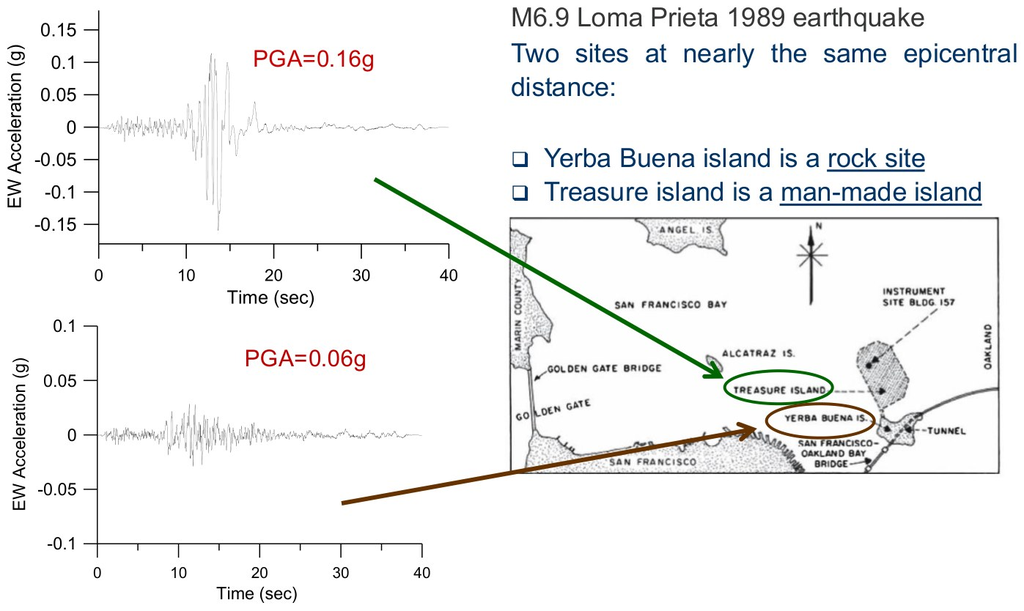

## Surface fault rupture

- **IM**: fault displacement $D$ where the asset crosses the fault; acceleration is irrelevant
- **Hazard**: fault displacement hazard analysis has the PSHA structure (Youngs et al., 2003), with $sr$: rupture reaches the surface; $\ell/L$: position along it

$$\lambda(D > d) = \sum_i \lambda(rup_i)\, P(sr \mid m_i)\, P(D > d \mid m_i, \ell/L)$$

- **Vulnerability**: can the asset accommodate the offset (ductility, sliding supports, routing)?
- **Exposure**: a *line* footprint: only assets crossing the fault are affected
- Trans-Alaska Pipeline, Denali 2002 ($M$ 7.9): designed for ≈ 6 m of offset, ≈ 4.3 m occurred, no oil spilled

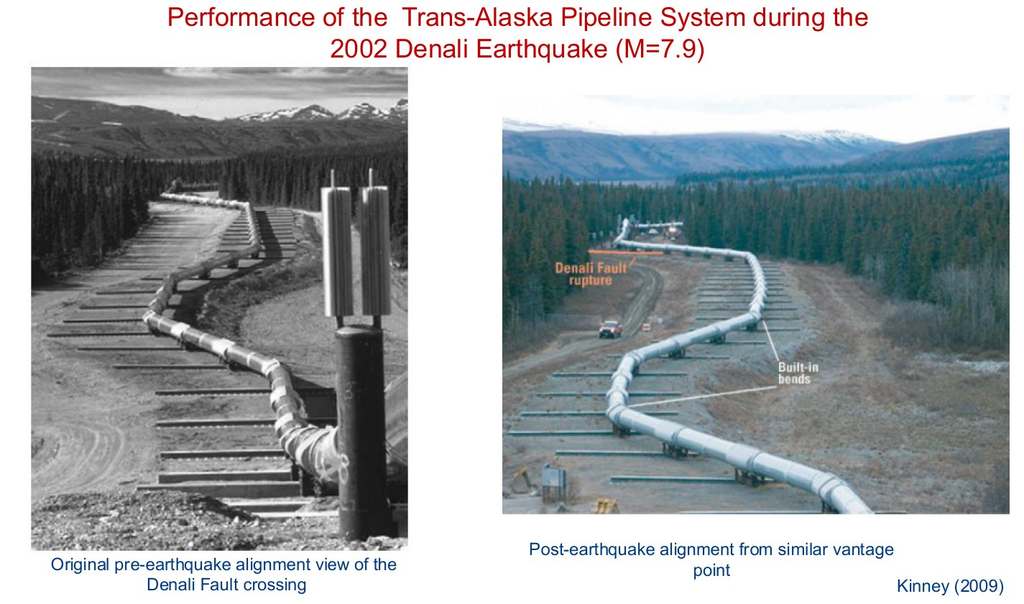

## Liquefaction

- **IM**: triggering depends on amplitude *and* number of cycles, so it needs the pair $(a_{max}, M)$:

$$FS_L = \frac{CRR_{7.5}\,MSF(M)}{CSR}, \quad CSR = 0.65\,\frac{a_{max}}{g}\,\frac{\sigma_v}{\sigma'_v}\,r_d$$

- **Hazard**: sum over all $(a_{max}, m)$ pairs from the PSHA disaggregation (Kramer & Mayfield, 2007)

$$\lambda(FS_L < fs) = \sum_i\sum_j P(FS_L < fs \mid a_i, m_j)\,\Delta\lambda(a_i, m_j)$$

- Damage is better predicted by consequences: settlement, lateral spread, LPI
- **Vulnerability**: foundation type, tolerance to differential settlement, buoyancy of buried structures

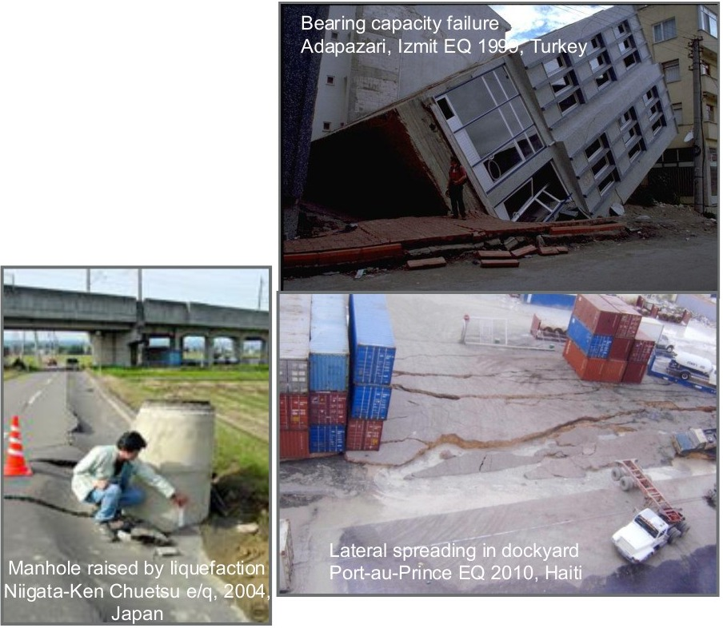

## Earthquake-induced landslides

- Newmark (1965): the sliding mass is a rigid block that slips whenever the ground acceleration exceeds its **critical acceleration** $a_c = (FS - 1)\, g \sin\alpha$
- **Response**: permanent displacement from the capacity/demand ratio, e.g. Jibson (2007), with $D_N$ in cm:

$$\log D_N = 0.215 + \log\!\left[\left(1 - \tfrac{a_c}{a_{max}}\right)^{2.341}\left(\tfrac{a_c}{a_{max}}\right)^{-1.438}\right]$$

- $a_c$ is a *capacity*, a property of the slope (like $\theta$ for a building); $a_{max}$ is the *demand*, from the hazard
- **Vulnerability & exposure**: assets *on* the slide respond to $D_N$; assets in the **run-out path** are usually destroyed, so $V \approx 1$ and risk is controlled by where they are

[figure not shown]

## Tsunamis

- Generated by sudden displacement of the sea floor (mainly subduction earthquakes), submarine landslides and volcanic flank collapse
- **IM**: inundation depth $h$, flow velocity $v$, momentum flux $hv^2$ (the drag on a structure scales with $\rho\, C_d\, b\, h v^2$)
- **Hazard**: probabilistic tsunami hazard analysis follows PSHA, but numerical simulation of propagation and inundation replaces the ground-motion model
- **Vulnerability**: fragility against $h$ by construction type: timber houses are washed away at depths that reinforced-concrete buildings survive (Suppasri et al., 2013)
- **Exposure**: a coastal band. For people, **warning time** vs evacuation time dominates: minutes for local sources, hours for distant ones

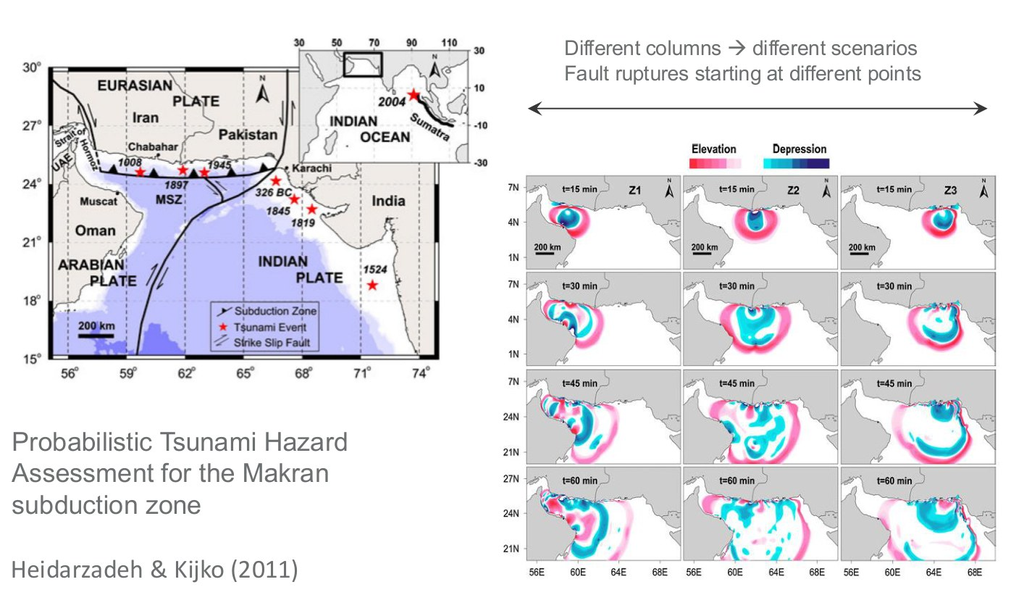

## Rainfall-triggered debris flows

- **Trigger**: rainfall intensity and duration, e.g. the global threshold $I = 14.82\,D^{-0.39}$ ($I$ in mm/h, $D$ in h; Caine, 1980)
- **Intensity at the site** depends on the run-out from source to site:
  - flow depth $h$ and velocity $v$
  - impact pressure $p \propto \rho v^2$
  - volume and boulder size
- Impacts change along the path: erosion and scour in the channel, impact and inundation on the fan
- **Vulnerability**: wall strength against $p$ and $h$; **exposure**: position on the fan

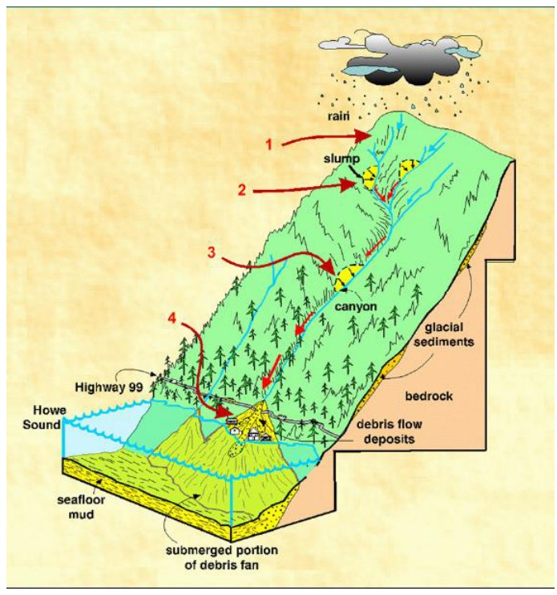

## Landslide risk: every term explicit

- Landslide practice writes the risk with each factor explicit (AGS, 2007; Fell et al., 2008):

$$R = P_{(L)} \times P_{(T:L)} \times P_{(S:T)} \times V_{(D:T)} \times E$$

- Mitigation targets specific terms:
  - $P_{(L)}$, annual probability of the landslide: drainage, runoff control
  - $P_{(T:L)}$, probability of reaching the element: barriers, check dams, catchment basins
  - $P_{(S:T)}$, probability the element is there: monitoring, warning, road closure
  - $V_{(D:T)}$, vulnerability: shelters and galleries
  - $E$, value at risk: zoning, relocation

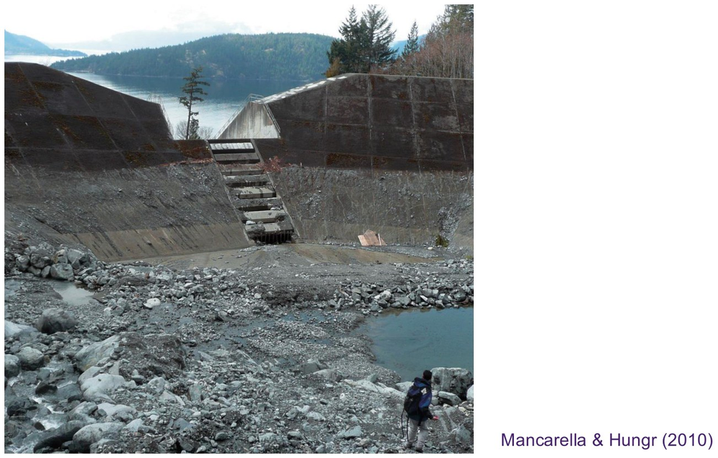

## Volcanic hazards

One volcano produces several hazards, each with its own IM and vulnerability:

| Phenomenon | IM | Vulnerability depends on | Reach |
| --- | --- | --- | --- |
| Tephra (ash) fall | load on roof (kPa) | roof span, pitch, material | up to ~1000 km |
| Pyroclastic density currents | dynamic pressure, temperature | wall strength, openings; people: $V \approx 1$ | ~10 km |
| Lava flows | inundation (yes/no) | $V \approx 1$: risk is set by exposure | ~10 km |
| Lahars | depth, velocity | as for debris flows | up to ~100 km |

- Evacuation, informed by monitoring, is the main mitigation for the most lethal phenomena

[figure not shown]

## One framework, many intensity measures

| Hazard | $IM$ | $EDP$ | Damage and loss drivers | Footprint |
| --- | --- | --- | --- | --- |
| Ground shaking | $S_a(T_1)$, PGA, PGV | drift, floor acceleration | collapse; repair cost; downtime | area |
| Surface rupture | offset $D$ | pipe or foundation strain | rupture, leaks, loss of service | line |
| Liquefaction | $(a_{max}, M)$, CAV | settlement, lateral spread | tilt, foundation failure, pipe breaks | patchy (geology) |
| Seismic landslides | $a_{max}$, Arias intensity | Newmark displacement $D_N$ | damage on the slide; burial in the run-out | slope and run-out |
| Tsunami | $h$, $v$, $hv^2$ | hydrodynamic force, scour | washed-away buildings; drowning (warning time) | coastal band |
| Debris flows | $h$, $v$ | impact pressure $\rho v^2$ | wall failure, burial | channel and fan |
| Volcanic | tephra load, PDC pressure | roof load | roof collapse; lethality (evacuation) | radial, 10–1000 km |

- The framework is unchanged across rows; what changes is the chain from $IM$ to $DV$, and each row would change again for a different loss metric

## Summary

- Risk combines hazard and vulnerability by **integrating over the intensity measure**, then summing over the exposed inventory
- Start from the problem: the **loss metric** ($DV$) determines which damage states matter, which demands cause them, and so which **IM** to compute the hazard for
- The same earthquake scenarios at the same site can therefore call for different IMs in different applications
- Every geohazard fits the same template. What changes is the $IM \rightarrow EDP \rightarrow DM \rightarrow DV$ chain and the model that carries the hazard to the site
- The rest of the module builds $\lambda(IM > im)$ for ground shaking, starting with the framework for seismic loading Lecture 1

## Exercise / Tutorial Problem

The seismic hazard at a site is $\lambda(PGA > a) = 10^{-3}\,(a/0.25\,g)^{-2.5}$. A structure has a lognormal collapse fragility with median $\theta = 0.6\,g$.

1. Compute the annual rate of collapse, $\lambda_C$, for $\beta = 0.3$ and for $\beta = 0.6$.
2. For each case, compute the probability of collapse in a 50-year design life.
3. A retrofit raises the median capacity to $\theta = 0.9\,g$ (with $\beta = 0.6$). By what factor does $\lambda_C$ fall?
4. Which is more effective: halving $\beta$ from 0.6 to 0.3, or raising $\theta$ from 0.6 to 0.9 *g*? Explain the result in terms of the hazard slope $k$.

## Bibliography

## Bibliography (continued)

CIVE70007 Geotechnical Hazards · L00 Introduction